# Linear model: Yogurt Fermentation!

In order to see which is the influence of the Temperature in the yogurt’s fermentation, some yogurts have been followed during their commercialization period. The experimental units are yogurts that have been analyzed several days after their fermentation. The data are contained in the file Iogurts.csv, and as variables it contains:

Two explanatory variables that are:

- *Days*: days between the fermentation and the day where it is performed the analysis.
- *Groups*: there are two groups of yogurts depending on their fermentation temperature, which are 42° and 43.5°.

Three response variables that have been rerecorded during the analysis, and that are:

- *pH*: the yogurt’s pH
- *Strep*: the concentration of Streptococcus salivarius thermophilus.
- *Lactob*: the concentration of Lactobacillus delbrueckii bulgaricus.

```r
setwd("~/Desktop/xperiments/Rii")
database<-read.csv2("Iogurt.csv")
head(database)
```

```
##   Ferm dia   pH strep lactob
## 1  T42  21 4.10  7.43   7.46
## 2  T42   0 4.44  7.65   7.75
## 3  T42  21 4.02  7.10   7.35
## 4  T42   7 4.24  7.54   7.62
## 5  T42   7 4.27  7.54   7.66
## 6  T42  28 4.01  7.25   7.41
```

*Shown above: some of the rows from the Iogurt.csv table.*

```r
library(car)
library(tables)
```

1- For each one of the response variables, we want to perform a dispersion diagram. Afterwards we will describe what do we deduce from it.

First of all, we are going to study how pH does change from one day to another due to the fermentation.

It is convenient to plot a *scatter plot* (also known as *dispersion diagram*). This can be done with the *scatter plot* command which is $sp(...)$. Then we define the variables: we want to put the pH as a function of the days, meaning that the days form the independent variable (the $x$ axis) and the pH - the dependent variable (on the $y$ axis). This is expressed as $pH\sim dia$. If we want to distinguish between different fermentation temperatures (42° and 43.5°), we have to condition on the fermentation. This can be done by $|Ferm$. Next we define which dataframe to use to perform the *scatter plot*, which is $database$.

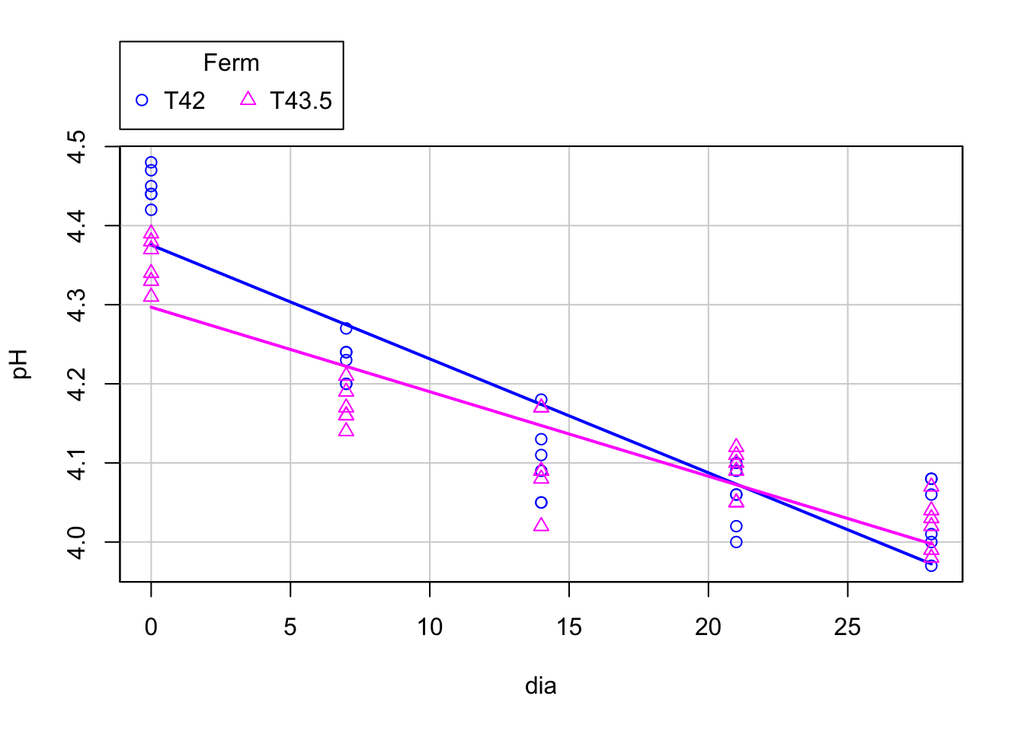

```r
sp(pH~dia|Ferm,database,smooth=F) # sp es scatter plot
```

We see that with the course of the days, the pH is decreasing. When the pH of the yogurt is lower than 4, it means that the yogurt is past its use-by date. Let’s have look on the plots of $bacteria\sim dia$.

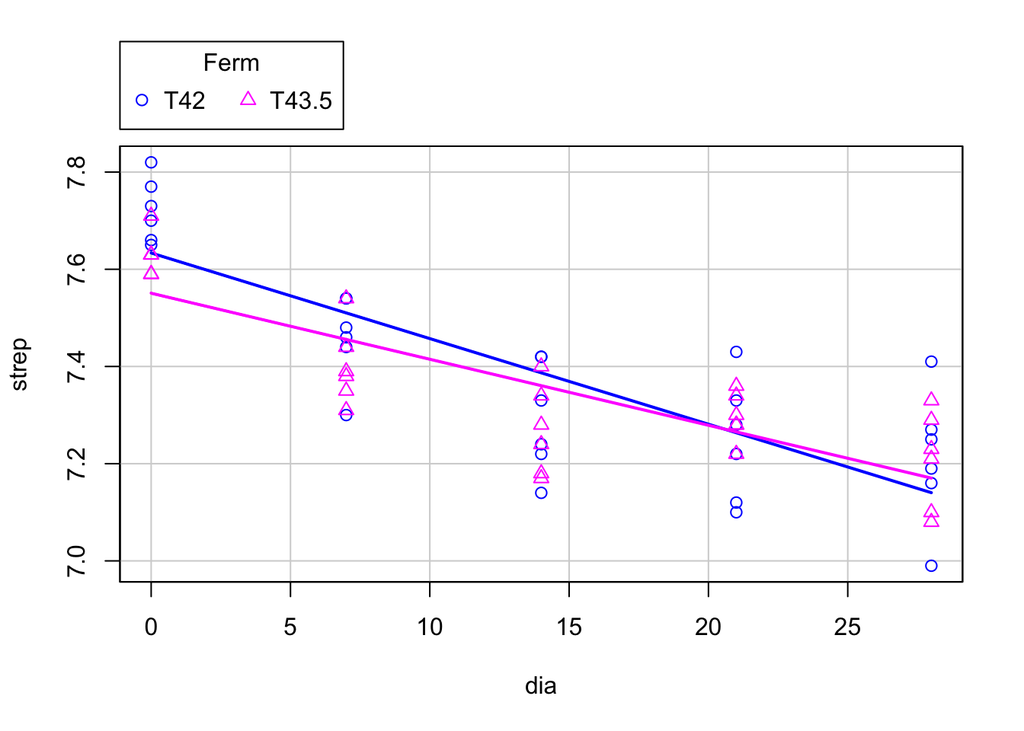

```r
sp(strep~dia|Ferm,smooth=F,database)
```

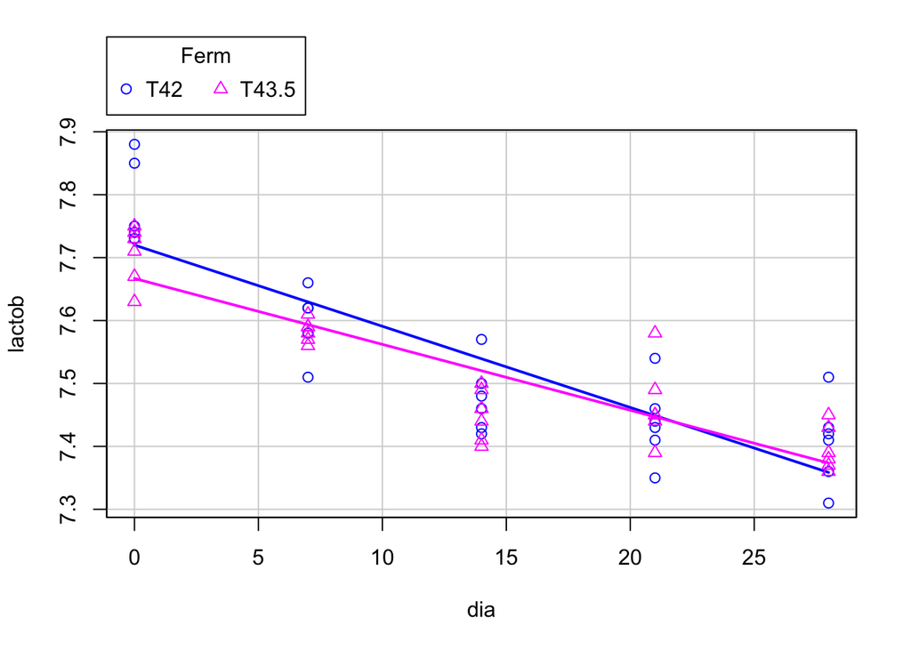

```r
sp(lactob~dia|Ferm,smooth=F,database)
```

We see that if the concentration of the bacteria is low, it cannot be called yogurt anymore, because the pH level decreases and yogurt goes bad.

2- We are going to perform a Table containing the basic descriptive measures for each one of the groups and each one of the days.

Tables can be created by using a spreadsheet or using R, with the *tables* package (we have already downloaded it earlier). Also, before starting, observe that for accessing to a parameter of a dataframe, we use the dolar symbol, like $database\$pH$. So, we have to distinguish between three components of table:

- *Factors*: these are categorical variables for grouping. For example: the temperature. We can factor a numeric variable by:

```r
database$Fdia <- as.factor(database$dia)
```

- *Variables*: we use one variable or more if we sum them (+), but we cannot combine variables (*).
- *Statistics*: examples of statistics are the *mean*, *standard deviation*… We cannot combine statistics with statistics, yet we can combine statistics with variables.

To create a table use $tabular(rows\sim columns)$:

```r
tabular((pH+strep+lactob)*Ferm*((n=1)+mean+sd)~Fdia,database) # n = nombre de dades, repliques i li posem el nom de n.
```

|  | Ferm |  | Fdia 0 | Fdia 7 | Fdia 14 | Fdia 21 | Fdia 28 |
| --- | --- | --- | --- | --- | --- | --- | --- |
| pH | T42 | n | 6.00000 | 6.00000 | 6.00000 | 6.00000 | 6.00000 |
|  |  | mean | 4.45000 | 4.23000 | 4.10167 | 4.05500 | 4.03333 |
|  |  | sd | 0.02191 | 0.02683 | 0.04997 | 0.03886 | 0.04633 |
|  | T43.5 | n | 6.00000 | 6.00000 | 6.00000 | 6.00000 | 6.00000 |
|  |  | mean | 4.35333 | 4.17167 | 4.10333 | 4.08667 | 4.02167 |
|  |  | sd | 0.03141 | 0.02483 | 0.05785 | 0.03011 | 0.03312 |
| strep | T42 | n | 6.00000 | 6.00000 | 6.00000 | 6.00000 | 6.00000 |
|  |  | mean | 7.72167 | 7.46000 | 7.29500 | 7.24667 | 7.21167 |
|  |  | sd | 0.06555 | 0.08854 | 0.11415 | 0.12644 | 0.13891 |
|  | T43.5 | n | 6.00000 | 6.00000 | 6.00000 | 6.00000 | 6.00000 |
|  |  | mean | 7.63000 | 7.40167 | 7.26833 | 7.29667 | 7.20667 |
|  |  | sd | 0.04382 | 0.08035 | 0.09042 | 0.04967 | 0.10013 |
| lactob | T42 | n | 6.00000 | 6.00000 | 6.00000 | 6.00000 | 6.00000 |
|  |  | mean | 7.78000 | 7.59500 | 7.47667 | 7.43833 | 7.40667 |
|  |  | sd | 0.06693 | 0.05128 | 0.05465 | 0.06242 | 0.06772 |
|  | T43.5 | n | 6.00000 | 6.00000 | 6.00000 | 6.00000 | 6.00000 |
|  |  | mean | 7.70500 | 7.58333 | 7.45000 | 7.46667 | 7.39667 |
|  |  | sd | 0.04637 | 0.01751 | 0.04099 | 0.06408 | 0.03559 |

3- Considering the pH as a response variable and fix a particular value for the variable Days. Assuming that the the response variables follows a Normal Distribution with constant variance and mean value that depends on the Group, with an alpha value equal to 0.05, we can wonder about:

- Whether there do exist some differences between the mean values for the pH for the two groups?
- Is it correct to assume that the variances of the pH variable in the two groups are equal?

To be able to guarantee that the mean values for the pH for the groups, $\mu_1$ and $\mu_2$, are different we need to check that with a test. Assuming

$X_1=pH|_{42, 0}\sim N(\mu_1,\sigma^2)$ $X_2=pH|_{43.5, 0}\sim N(\mu_1,\sigma^2)$

In case the variances are the same we can use the T-Student test, Fisher and other exact distributions. However, when the variances are different, we can have just an approximation (using T-student with degrees of freedom). When we are asking about similar things (like the mean values for the pH with similar temperatures) we can assume the same variance, since, in general, it varies just a bit.